# Su et al., (2024): Figure 3

# Load and tidy data

Data was exported from VideoFreeze as CSV files. The header rows of the raw CSV files contain information regarding how the data was exported (ie how data was segmented into bins as well as what motion index threshold was used as a cut-off for assessing freezing).

```r
# df ---------------------------------------------------

list.files(pattern=".csv$", recursive = TRUE)
```

```
##  [1] "2022-10-25_PREE#14/22-10-25_FC1_10.csv"
##  [2] "2022-10-25_PREE#14/22-10-25_FC1_100.csv"
##  [3] "2022-10-25_PREE#14/22-10-26_FC2_10.csv"
##  [4] "2022-10-25_PREE#14/22-10-26_FC2_100.csv"
##  [5] "2022-10-25_PREE#14/22-10-27_E1.csv"
##  [6] "2022-10-25_PREE#14/22-10-28_E2.csv"
##  [7] "2022-10-25_PREE#14/22-10-29_E3.csv"
##  [8] "2022-10-25_PREE#14/22-10-31_ER.csv"
##  [9] "2022-10-25_PREE#14/22-11-28_SR.csv"
## [10] "2022-11-05_PREE#15/22-11-05_FC1.csv"
## [11] "2022-11-05_PREE#15/22-11-06_FC2.csv"
## [12] "2022-11-05_PREE#15/22-11-07_E1.csv"
## [13] "2022-11-05_PREE#15/22-11-08_E2.csv"
## [14] "2022-11-05_PREE#15/22-11-09_E3.csv"
## [15] "2022-11-05_PREE#15/22-11-11_ER.csv"
## [16] "2022-11-05_PREE#15/22-12-10_SR.csv"
## [17] "metadata.csv"
```

```r
list.filenames <- list.files(".", pattern = ".csv$",
                             full.names=TRUE, recursive = TRUE)
# delete the metadata from the list.filenames
list.filenames <- list.filenames[!(str_detect(list.filenames, "metadata"))]
list.filenames
```

```
##  [1] "./2022-10-25_PREE#14/22-10-25_FC1_10.csv"
##  [2] "./2022-10-25_PREE#14/22-10-25_FC1_100.csv"
##  [3] "./2022-10-25_PREE#14/22-10-26_FC2_10.csv"
##  [4] "./2022-10-25_PREE#14/22-10-26_FC2_100.csv"
##  [5] "./2022-10-25_PREE#14/22-10-27_E1.csv"
##  [6] "./2022-10-25_PREE#14/22-10-28_E2.csv"
##  [7] "./2022-10-25_PREE#14/22-10-29_E3.csv"
##  [8] "./2022-10-25_PREE#14/22-10-31_ER.csv"
##  [9] "./2022-10-25_PREE#14/22-11-28_SR.csv"
## [10] "./2022-11-05_PREE#15/22-11-05_FC1.csv"
## [11] "./2022-11-05_PREE#15/22-11-06_FC2.csv"
## [12] "./2022-11-05_PREE#15/22-11-07_E1.csv"
## [13] "./2022-11-05_PREE#15/22-11-08_E2.csv"
## [14] "./2022-11-05_PREE#15/22-11-09_E3.csv"
## [15] "./2022-11-05_PREE#15/22-11-11_ER.csv"
## [16] "./2022-11-05_PREE#15/22-12-10_SR.csv"
```

```r
metadata <- read.csv("metadata.csv")
list.data <- list()

for (i in 1:length(list.filenames)) {
  list.data[[i]] <- read.csv(list.filenames[[i]], skip=
                               ifelse(str_detect(list.filenames[[i]], "FC\\w*10.csv$"), 42,
                                      ifelse(str_detect(list.filenames[[i]], "FC\\w*100.csv$"), 15,
                                             ifelse(str_detect(list.filenames[[i]], "FC1.csv$"), 18,
                                                    ifelse(str_detect(list.filenames[[i]], "FC2.csv$"), 18,
                                                          ifelse(str_detect(list.filenames[[i]], "ER"), 16,
                                                                 ifelse(str_detect(list.filenames[[i]], "SR"), 16,
                                                                        24))))))
  )
  list.data[[i]]$ExpDetails <- str_sub(list.filenames[[i]], 22, -5)
  #remove the first and last characters
  list.data[[i]] <- dplyr::select(list.data[[i]], -c(Animal, Group))
}

list.data <- list.data %>%
  reduce(full_join) %>% #collapse separate items in list into one
  separate(col=ExpDetails, into = c("Exp_Date", "Exp_Type"), sep = "_")
```

[output not shown]

```r
# Conver list into a dataframe
df<-as.data.frame(list.data)
# Join df and metadata
df<- full_join(df, metadata,  by= c("Exp_Type", "Exp_Date", "Box", "Trial"))


df<- df%>%
  mutate(id= paste(Group, Cage, Animal, sep="_")) %>%
  mutate(Trial=as.factor(Trial)) %>%
  mutate(CS_Time=as.factor(CS_Time)) %>%
  mutate(Contingency=ifelse(
    str_detect(Group, "10$"), "10%",
    ifelse(str_detect(Group, "100$"),"100%",
           ifelse(str_detect(Group, "50$"),"50%", NA
                  ))))

rm(list=setdiff(ls(), "df"))
df<- df %>%
  drop_na(Trial, Strain, Experiment)

df$Contingency <- factor(df$Contingency, levels = c("100%", "50%", "10%"))
```

# Fig 3. Lower US strength (0.3mA) & partial reinforcement alter fear learning but do not affect fear extinction.

## B. Fear Acquisition

### B - Dataframe

Compare the average percent time freezing during CS presentations across the two days of FC training

```r
FC_id_1 <- df %>%
  filter(str_detect(Component.Name, "pre-tone|post-tone", negate = TRUE),
         str_detect(Exp_Type, "FC")) %>%
  mutate(Condition = ifelse(
    str_detect(Exp_Type, "FC"), "FC", NA)) %>%
  group_by(id, Group, Contingency, Condition) %>%
  summarize(mean_freezing=mean(Pct.Component.Time.Freezing), n=n(),
            se=sd(Pct.Component.Time.Freezing/sqrt(n())))
FC_ave_1 <- FC_id_1 %>%
  group_by(Group, Contingency) %>%
  summarize(group_mean_freezing=mean(mean_freezing), n=n(),
            se=sd(mean_freezing/sqrt(n())))
#write_csv(FC_ave, "220803_PREE_FC_ave.csv")
```

### B - Graph

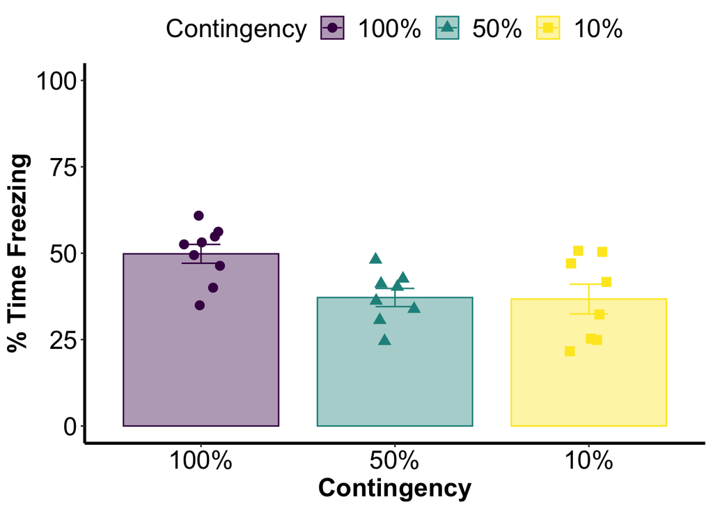

```r
ggplot(FC_ave_1,
       aes(x=Contingency,
           y=group_mean_freezing,
           group=Contingency,
           color=Contingency,
           fill=Contingency,
           shape=Contingency)) +
  scale_fill_viridis(discrete = TRUE) +
  scale_colour_viridis(discrete = TRUE) +
  geom_bar(
    stat = "identity",
    position = "dodge",
    width=0.8,
    alpha=0.4) +
  geom_errorbar(
    aes(
      ymin = group_mean_freezing-se,
      ymax = group_mean_freezing+se,
      width = .2),
    position=position_dodge(width=0.8)
  ) +
  geom_point(
    data=FC_id_1,
    aes(x=Contingency, y=mean_freezing),
    position = position_jitterdodge(jitter.height=0, jitter.width=0.5,
                                    dodge.width = 0.8),
    size=3
  ) +
  ylim(0,100) +
  theme_bw() +
  theme(legend.text=element_text(size=18),
        legend.title = element_text(size=18),
        legend.position = "top",
        panel.border= element_blank(),
        plot.background = element_blank(),
        plot.title = element_text(size = 18,face="bold.italic", hjust=0.5),
        panel.grid.major = element_blank(),
        panel.grid.minor = element_blank(),
        axis.text.x = element_text(size = 18, color="black"),
        axis.text.y = element_text(size = 18, color="black"),
        axis.title.x = element_text(size = 18, face= "bold"),
        axis.title.y = element_text(size = 18, face="bold"),
        axis.line.x = element_line(color="black", size = 1),
        axis.line.y = element_line(color="black", size = 1),
        strip.text = element_text(size = 18)) +
  labs(
    x = "Contingency",
    y = "% Time Freezing")
```

### B - Stats

```r
m3b <- FC_id_1 %>%
  aov_ez(id = "id",
         dv = "mean_freezing",
         between = "Contingency",
         within = ,
         data = .)
```

```
## Contrasts set to contr.sum for the following variables: Contingency
```

```r
#ANOVA table
nice_m3b <-nice(m3b)
kable(nice_m3b, caption = '<b>Figure 3B: Main FX</b>') %>%
  kable_styling(bootstrap_options = "striped", full_width = F, position = "left")
```

**Figure 3B: Main FX**

| Effect | df | MSE | F | ges | p.value |
| --- | --- | --- | --- | --- | --- |
| Contingency | 2, 22 | 89.01 | 5.36 * | .327 | .013 |

```r
#Simple contrasts for Contingency
n3b <- emmeans(m3b, ~Contingency)
n3b_pairs <- pairs(n3b, simple="Contingency")
kable(n3b_pairs, caption = '<b>Figure 3B: Simple Contrasts for Contingency</b>')
```

**Figure 3B: Simple Contrasts for Contingency**

| contrast | estimate | SE | df | t.ratio | p.value |
| --- | --- | --- | --- | --- | --- |
| 100% - 50% | 12.6397083 | 4.584378 | 22 | 2.7571261 | 0.0297352 |
| 100% - 10% | 13.0798750 | 4.584378 | 22 | 2.8531405 | 0.0241157 |
| 50% - 10% | 0.4401667 | 4.717286 | 22 | 0.0933093 | 0.9952124 |

## C. Fear Retrieval

Retrieval was evaluated as the proportion of time freezing between two CS epochs: (1) CS freezing on FC Day 2 and (2) the first four CS presentations on Extinction Day 1

### C - Dataframe

```r
E1_Session1_id_1 <- df %>%
  filter(str_detect(Experiment, "E1"),
         str_detect(Experiment, "ER", negate = TRUE),
         str_detect(Component.Name,  "tone 01|tone 02|tone 03|tone 04")) %>%
  group_by(id, Group, CS_Time, Contingency, Exp_Type) %>%
  summarize(mean_freezing=mean(Pct.Component.Time.Freezing), n=n(),
            se=sd(Pct.Component.Time.Freezing/sqrt(n())))
```

```
## You can override using the `.groups` argument.
```

```r
E1_Session1_ave_1 <- E1_Session1_id_1 %>%
  group_by(CS_Time, Group, Contingency, Exp_Type) %>%
  summarize(group_mean_freezing=mean(mean_freezing), n=n(),
            se=sd(mean_freezing/sqrt(n())))
FC2_id_1 <- df %>%
  filter(str_detect(Component.Name, "pre-tone|post-tone", negate = TRUE),
         str_detect(Exp_Type, "FC2")) %>%
  group_by(id, Group, CS_Time, Contingency, Exp_Type) %>%
  summarize(mean_freezing=mean(Pct.Component.Time.Freezing), n=n(),
            se=sd(Pct.Component.Time.Freezing/sqrt(n())))
```

```
## You can override using the `.groups` argument.
```

```r
FC2_ave_1 <- FC2_id_1 %>%
  group_by(CS_Time, Group, Contingency, Exp_Type) %>%
  summarize(group_mean_freezing=mean(mean_freezing), n=n(),
            se=sd(mean_freezing/sqrt(n())))
E1_FC2_ave_1 <-rbind(E1_Session1_ave_1, FC2_ave_1)
E1_FC2_ave_1 <- E1_FC2_ave_1 %>%
  mutate(Exp_Type = if_else(Exp_Type == "E1", "Session 1", Exp_Type))

E1_FC2_id_1 <-rbind(E1_Session1_id_1, FC2_id_1)
E1_FC2_id_1 <- E1_FC2_id_1 %>%
  mutate(Exp_Type = if_else(Exp_Type == "E1", "Session 1", Exp_Type))
```

### C - Graph

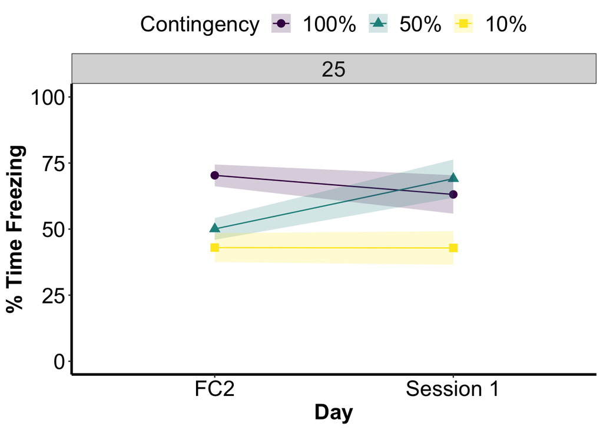

```r
ggplot(
  E1_FC2_ave_1,
  aes(x=Exp_Type,
      y=group_mean_freezing,
      group = Contingency,
      color = Contingency,
      fill = Contingency,
      shape = Contingency)) +
  scale_fill_viridis(discrete = TRUE) +
  scale_colour_viridis(discrete = TRUE) +
  geom_point(
    size = 3
  ) +
  geom_line(
  ) +
  facet_wrap(
    vars(CS_Time)
  ) +
  ylim(0,100) +
  geom_ribbon(
    aes(
      ymin = group_mean_freezing-se,
      ymax = group_mean_freezing+se),
    alpha = .2,
    color = NA
  ) +
  theme_bw() +
  theme(legend.text=element_text(size=18),
        legend.title = element_text(size=18),
        legend.position = "top",
        panel.border= element_blank(),
        plot.background = element_blank(),
        plot.title = element_text(size = 18,face="bold.italic", hjust=0.5),
        panel.grid.major = element_blank(),
        panel.grid.minor = element_blank(),
        axis.text.x = element_text(size = 18, color="black"),
        axis.text.y = element_text(size = 18, color="black"),
        axis.title.x = element_text(size = 18, face= "bold"),
        axis.title.y = element_text(size = 18, face="bold"),
        axis.line.x = element_line(color="black", size = 1),
        axis.line.y = element_line(color="black", size = 1),
        strip.text = element_text(size = 18)) +
  labs(
    x = "Day",
    y = "% Time Freezing")
```

### C - Stats

```r
m3c <- E1_FC2_id_1 %>%
  aov_ez(id = "id",
         dv = "mean_freezing",
         between = "Contingency",
         within = "Exp_Type",
         data = .)
```

```
## Contrasts set to contr.sum for the following variables: Contingency
```

```r
#ANOVA table
nice_m3c <-nice(m3c)
kable(nice_m3c, caption = '<b>Figure 3C: Main FX</b>') %>%
  kable_styling(bootstrap_options = "striped", full_width = F, position = "left")
```

**Figure 3C: Main FX**

| Effect | df | MSE | F | ges | p.value |
| --- | --- | --- | --- | --- | --- |
| Contingency | 2, 21 | 266.61 | 8.95 ** | .289 | .002 |
| Exp_Type | 1, 21 | 292.68 | 0.62 | .015 | .440 |
| Contingency:Exp_Type | 2, 21 | 292.68 | 2.52 | .112 | .104 |

```r
#Simple contrasts for Contingency
n3c <- emmeans(m3c, ~ Contingency)
n3c_pairs <- pairs(n3c, simple="Contingency")
kable(n3b_pairs, caption = '<b>Figure 3C: Simple Contrasts for Contingency</b>')
```

| contrast | estimate | SE | df | t.ratio | p.value |
| --- | --- | --- | --- | --- | --- |
| 100% - 50% | 12.6397083 | 4.584378 | 22 | 2.7571261 | 0.0297352 |
| 100% - 10% | 13.0798750 | 4.584378 | 22 | 2.8531405 | 0.0241157 |
| 50% - 10% | 0.4401667 | 4.717286 | 22 | 0.0933093 | 0.9952124 |

## D. Extinction Acquisition

To evaluate the effect of partial reinforcement on fear extinction acquisition, mice were exposed to 12 unreinforced CS presentations for three consecutive days (E1, E2, E3) in a novel context (Context B). Percent time freezing was averaged in bins composed of 3CS presentations.

### D - Dataframe

```r
bin1 =c("tone 01", "tone 02", "tone 03")
bin2 =c("tone 04", "tone 05", "tone 06")
bin3 =c("tone 07", "tone 08", "tone 09")
bin4 =c("tone 10", "tone 11", "tone 12")


EXT_bin_id_1 <- df %>%
  filter(str_detect(Experiment, "E"),
         str_detect(Experiment, "ER", negate = TRUE)) %>%
  mutate(Bin = ifelse(Component.Name %in% "pre-tone", "Pre",
                      ifelse(Component.Name %in% bin1, "1",
                             ifelse(Component.Name %in% bin2, "2",
                                    ifelse(Component.Name %in% bin3, "3",
                                           ifelse(Component.Name %in% bin4, "4", "Post")))))) %>%
  group_by(Exp_Type, id, Group, CS_Time, Contingency, Bin) %>%
  summarize(mean_freezing=mean(Pct.Component.Time.Freezing), n=n(),
            se=sd(Pct.Component.Time.Freezing/sqrt(n())))
```

```
## 'Contingency'. You can override using the `.groups` argument.
```

```r
EXT_bin_ave_1 <- EXT_bin_id_1 %>%
  group_by(Exp_Type, Bin, Group, CS_Time, Contingency) %>%
  summarize(group_mean_freezing=mean(mean_freezing), n=n(),
            se=sd(mean_freezing/sqrt(n())))
```

```
## can override using the `.groups` argument.
```

```r
EXT_bin_ave_1$Bin <- factor(EXT_bin_ave_1$Bin, levels = c("Pre", "1", "2", "3", "4", "5", "6", "Post"))
```

### D - Graph

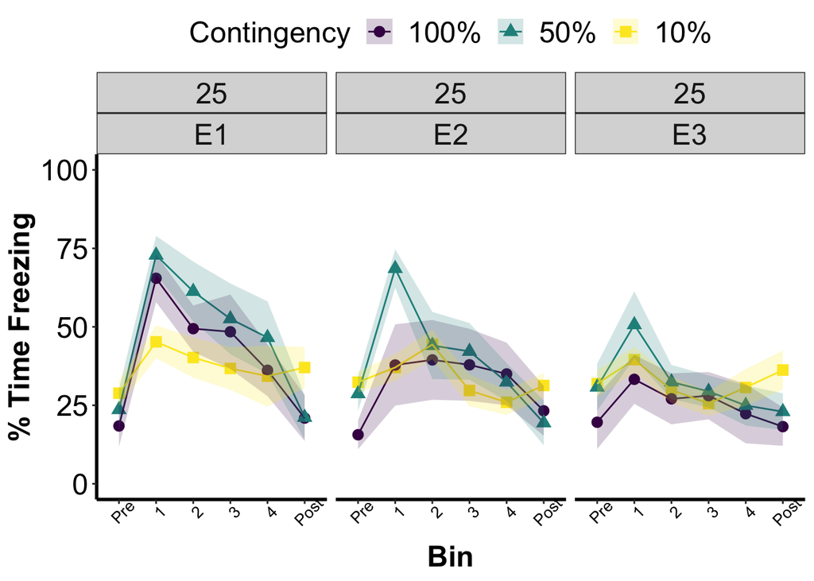

```r
ggplot(
  data = subset(EXT_bin_ave_1, !is.na(Bin)),
  aes(x=Bin,
      y=group_mean_freezing,
      group = Contingency,
      color = Contingency,
      fill = Contingency,
      shape=Contingency)) +
  facet_wrap(
    vars(CS_Time, Exp_Type)
  ) +
  scale_fill_viridis(discrete = TRUE) +
  scale_colour_viridis(discrete = TRUE) +
  geom_point(
    size = 3
  ) +
  geom_line(
  ) +
  ylim(0,100) +
  geom_ribbon(
    aes(
      ymin = group_mean_freezing-se,
      ymax = group_mean_freezing+se),
    alpha = .2,
    color = NA
  ) +
  theme_bw() +
  theme(legend.text=element_text(size=18),
        legend.title = element_text(size=18),
        legend.position = "top",
        panel.border= element_blank(),
        plot.background = element_blank(),
        plot.title = element_text(size = 18,face="bold.italic", hjust=0.5),
        panel.grid.major = element_blank(),
        panel.grid.minor = element_blank(),
        axis.text.x = element_text(size = 10, color="black", angle = 45),
        axis.text.y = element_text(size = 18, color="black"),
        axis.title.x = element_text(size = 18, face= "bold"),
        axis.title.y = element_text(size = 18, face="bold"),
        axis.line.x = element_line(color="black", size = 1),
        axis.line.y = element_line(color="black", size = 1),
        strip.text = element_text(size = 18)) +
  labs(
    x = "Bin",
    y = "% Time Freezing")
```

```r
m3d <- EXT_bin_id_1 %>%
  filter(Bin != "Pre" & Bin !="Post") %>%
  aov_ez(id = "id",
         dv = "mean_freezing",
         between = "Contingency",
         within = c("Exp_Type", "Bin"),
         data = .)
```

```
## Contrasts set to contr.sum for the following variables: Contingency
```

```r
#ANOVA table
nice_m3d <-nice(m3d)
kable(nice_m3d, caption = '<b>Figure 3D: Main FX</b>') %>%
  kable_styling(bootstrap_options = "striped", full_width = F, position = "left")
```

**Figure 3D: Main FX**

| Effect | df | MSE | F | ges | p.value |
| --- | --- | --- | --- | --- | --- |
| Contingency | 2, 21 | 3381.18 | 1.00 | .048 | .385 |
| Exp_Type | 1.65, 34.74 | 869.77 | 10.75 *** | .103 | <.001 |
| Contingency:Exp_Type | 3.31, 34.74 | 869.77 | 0.90 | .019 | .460 |
| Bin | 2.67, 56.13 | 245.34 | 19.33 *** | .086 | <.001 |
| Contingency:Bin | 5.35, 56.13 | 245.34 | 2.41 * | .023 | .044 |
| Exp_Type:Bin | 2.95, 61.88 | 312.63 | 0.78 | .005 | .509 |
| Contingency:Exp_Type:Bin | 5.89, 61.88 | 312.63 | 1.26 | .017 | .291 |

```r
#Simple contrasts for Contingency and CS-bin
n3d <- emmeans(m3d, ~Contingency * Bin * Exp_Type)
n3d_pairs <- pairs(n3d, simple=c("Contingency", "Bin"))
kable(n3d_pairs, caption = '<b>Figure 3D: Simple Contrasts for Contingency and CS-Bin</b>')
```

**Figure 3D: Simple Contrasts for Contingency and CS-Bin**

| contrast | Exp_Type | estimate | SE | df | t.ratio | p.value |
| --- | --- | --- | --- | --- | --- | --- |
| 100% X1 - 50% X1 | E1 | -7.3683333 | 9.025929 | 21 | -0.8163518 | 0.9993092 |
| 100% X1 - 10% X1 | E1 | 20.2541667 | 9.025929 | 21 | 2.2439980 | 0.5392013 |
| 100% X1 - 100% X2 | E1 | 16.0491667 | 4.361782 | 21 | 3.6794975 | 0.0476341 |
| 100% X1 - 50% X2 | E1 | 4.1929167 | 10.134359 | 21 | 0.4137328 | 0.9999992 |
| 100% X1 - 10% X2 | E1 | 25.2591667 | 10.134359 | 21 | 2.4924287 | 0.3942497 |
| 100% X1 - 100% X3 | E1 | 17.0425000 | 7.478550 | 21 | 2.2788509 | 0.5179400 |
| 100% X1 - 50% X3 | E1 | 12.9158333 | 12.052033 | 21 | 1.0716726 | 0.9928991 |
| 100% X1 - 10% X3 | E1 | 28.7320833 | 12.052033 | 21 | 2.3840031 | 0.4553318 |
| 100% X1 - 100% X4 | E1 | 29.3050000 | 7.757349 | 21 | 3.7777079 | 0.0388471 |
| 100% X1 - 50% X4 | E1 | 18.8879167 | 11.808316 | 21 | 1.5995436 | 0.8910047 |
| 100% X1 - 10% X4 | E1 | 31.1879167 | 11.808316 | 21 | 2.6411823 | 0.3180565 |
| 50% X1 - 10% X1 | E1 | 27.6225000 | 9.025929 | 21 | 3.0603498 | 0.1586247 |
| 50% X1 - 100% X2 | E1 | 23.4175000 | 10.134359 | 21 | 2.3107036 | 0.4986988 |
| 50% X1 - 50% X2 | E1 | 11.5612500 | 4.361782 | 21 | 2.6505794 | 0.3135745 |
| 50% X1 - 10% X2 | E1 | 32.6275000 | 10.134359 | 21 | 3.2194932 | 0.1183667 |
| 50% X1 - 100% X3 | E1 | 24.4108333 | 12.052033 | 21 | 2.0254536 | 0.6736356 |
| 50% X1 - 50% X3 | E1 | 20.2841667 | 7.478550 | 21 | 2.7123128 | 0.2851598 |
| 50% X1 - 10% X3 | E1 | 36.1004167 | 12.052033 | 21 | 2.9953799 | 0.1780380 |
| 50% X1 - 100% X4 | E1 | 36.6733333 | 11.808316 | 21 | 3.1057207 | 0.1461260 |
| 50% X1 - 50% X4 | E1 | 26.2562500 | 7.757349 | 21 | 3.3846935 | 0.0862001 |
| 50% X1 - 10% X4 | E1 | 38.5562500 | 11.808316 | 21 | 3.2651776 | 0.1085652 |
| 10% X1 - 100% X2 | E1 | -4.2050000 | 10.134359 | 21 | -0.4149251 | 0.9999992 |
| 10% X1 - 50% X2 | E1 | -16.0612500 | 10.134359 | 21 | -1.5848314 | 0.8964561 |
| 10% X1 - 10% X2 | E1 | 5.0050000 | 4.361782 | 21 | 1.1474667 | 0.9879050 |
| 10% X1 - 100% X3 | E1 | -3.2116667 | 12.052033 | 21 | -0.2664834 | 1.0000000 |
| 10% X1 - 50% X3 | E1 | -7.3383333 | 12.052033 | 21 | -0.6088876 | 0.9999575 |
| 10% X1 - 10% X3 | E1 | 8.4779167 | 7.478550 | 21 | 1.1336311 | 0.9889767 |
| 10% X1 - 100% X4 | E1 | 9.0508333 | 11.808316 | 21 | 0.7664796 | 0.9996130 |
| 10% X1 - 50% X4 | E1 | -1.3662500 | 11.808316 | 21 | -0.1157024 | 1.0000000 |
| 10% X1 - 10% X4 | E1 | 10.9337500 | 7.757349 | 21 | 1.4094699 | 0.9487244 |

[output cut: 168 more lines]

## E. Extinction Consolidation

We investigated whether partial reinforcement could affect 24-hr consolidation of extinction learning across the three extinction sessions. For this analysis we averaged percent time freezing across all CS presentations per extinction training day.

### E - Dataframe

```r
EXT_id_1 <- df %>%
  filter(str_detect(Component.Name, "pre-tone|post-tone", negate = TRUE),
         str_detect(Exp_Type, "E"),
         str_detect(Exp_Type, "ER", negate = TRUE)) %>%
  group_by(Exp_Type, id, Group, CS_Time, Contingency) %>%
  summarize(mean_freezing=mean(Pct.Component.Time.Freezing), n=n(),
            se=sd(Pct.Component.Time.Freezing/sqrt(n())))
```

```
## can override using the `.groups` argument.
```

```r
EXT_ave_1 <- EXT_id_1 %>%
  group_by(Exp_Type, CS_Time, Group, Contingency) %>%
  summarize(group_mean_freezing=mean(mean_freezing), n=n(),
            se=sd(mean_freezing/sqrt(n())))
```

### E - Graph

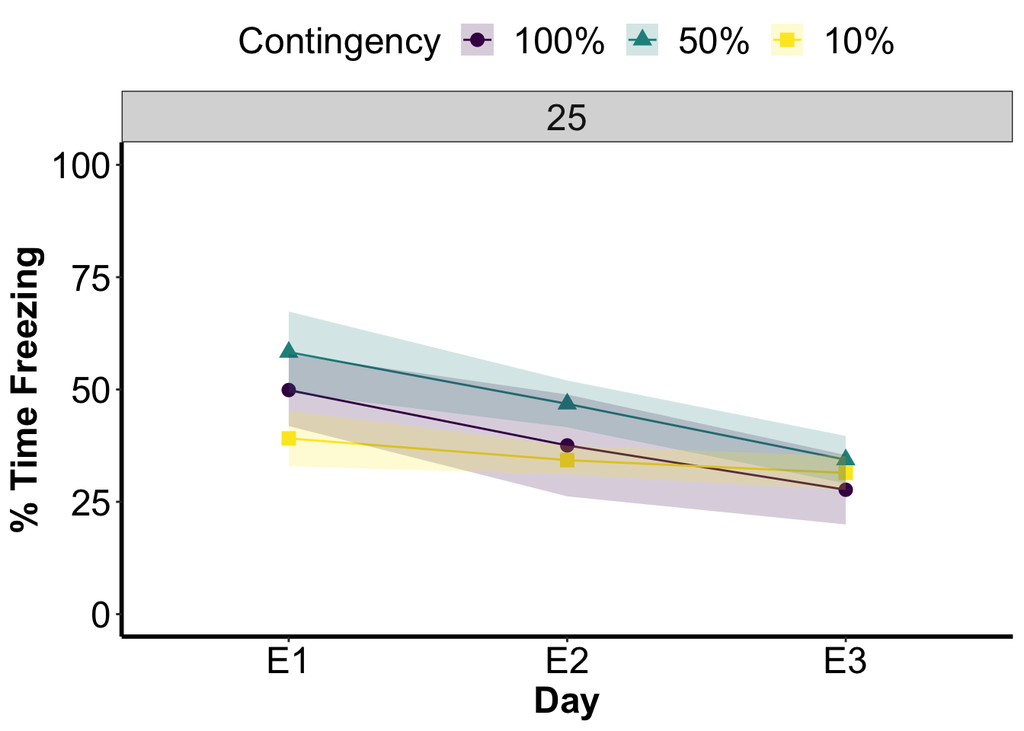

```r
ggplot(
  EXT_ave_1,
  aes(x=Exp_Type,
      y=group_mean_freezing,
      group = Contingency,
      color = Contingency,
      fill = Contingency,
      shape = Contingency)) +
  scale_fill_viridis(discrete = TRUE) +
  scale_colour_viridis(discrete = TRUE) +
  geom_point(
    size = 3
  ) +
  geom_line(
  ) +
  facet_wrap(
    vars(CS_Time)
  ) +
  ylim(0,100) +
  geom_ribbon(
    aes(
      ymin = group_mean_freezing-se,
      ymax = group_mean_freezing+se),
    alpha = .2,
    color = NA
  ) +
  theme_bw() +
  theme(legend.text=element_text(size=18),
        legend.title = element_text(size=18),
        legend.position = "top",
        panel.border= element_blank(),
        plot.background = element_blank(),
        plot.title = element_text(size = 18,face="bold.italic", hjust=0.5),
        panel.grid.major = element_blank(),
        panel.grid.minor = element_blank(),
        axis.text.x = element_text(size = 18, color="black"),
        axis.text.y = element_text(size = 18, color="black"),
        axis.title.x = element_text(size = 18, face= "bold"),
        axis.title.y = element_text(size = 18, face="bold"),
        axis.line.x = element_line(color="black", size = 1),
        axis.line.y = element_line(color="black", size = 1),
        strip.text = element_text(size = 18)) +
  labs(
    x = "Day",
    y = "% Time Freezing")
```

### E - Stats

```r
#Simple contrasts for Extinction Session
n3e <- emmeans(m3d, ~ Exp_Type)
n3e_pairs <- pairs(n3e, simple=c("Exp_Type"))
kable(n3e_pairs, caption = '<b>Figure 3E: Simple Contrasts for Extinction Session</b>')
```

**Figure 3E: Simple Contrasts for Extinction Session**

| contrast | estimate | SE | df | t.ratio | p.value |
| --- | --- | --- | --- | --- | --- |
| E1 - E2 | 9.555035 | 4.214608 | 21 | 2.267123 | 0.0829928 |
| E1 - E3 | 17.939028 | 4.361975 | 21 | 4.112593 | 0.0013827 |
| E2 - E3 | 8.383993 | 2.859560 | 21 | 2.931917 | 0.0208527 |

## F. Extinction Recall ————————————————————-

Extinction recall was measured at recent (48 h) or remote (30 d) timepoints. Mice were returned to Context B and received a tone test (4 CS presentations) 48 hours and 30 days after the last day of extinction training. In addition to comparing experimental groups at each time point, we also compared percent time freezing within-subjects between the recent and remote time points to assess the level of spontaneous recovery, or the return of conditioned fear with the passage of time

### F - Dataframe

```r
ER_id_1 <- df %>%
  filter(str_detect(Component.Name, "pre-tone|post-tone", negate = TRUE),
         str_detect(Exp_Type, "ER")) %>%
  group_by(id, Group, CS_Time, Contingency, Exp_Type) %>%
  summarize(mean_freezing=mean(Pct.Component.Time.Freezing), n=n(),
            se=sd(Pct.Component.Time.Freezing/sqrt(n())))
```

```
## You can override using the `.groups` argument.
```

```r
ER_ave_1 <- ER_id_1 %>%
  group_by(CS_Time, Group, Contingency, Exp_Type) %>%
  summarize(group_mean_freezing=mean(mean_freezing), n=n(),
            se=sd(mean_freezing/sqrt(n())))
E3_id_1 <- df %>%
  filter(str_detect(Component.Name, "pre-tone|post-tone", negate = TRUE),
         str_detect(Exp_Type, "E3")) %>%
  group_by(id, Group, CS_Time, Contingency, Exp_Type) %>%
  summarize(mean_freezing=mean(Pct.Component.Time.Freezing), n=n(),
            se=sd(Pct.Component.Time.Freezing/sqrt(n())))
```

```
## You can override using the `.groups` argument.
```

```r
E3_ave_1 <- E3_id_1 %>%
  group_by(CS_Time, Group, Contingency, Exp_Type) %>%
  summarize(group_mean_freezing=mean(mean_freezing), n=n(),
            se=sd(mean_freezing/sqrt(n())))
SR_id_1 <- df %>%
  filter(str_detect(Component.Name, "pre-tone|post-tone", negate = TRUE),
         str_detect(Exp_Type, "SR")) %>%
  group_by(id, Group, CS_Time, Contingency, Exp_Type) %>%
  summarize(mean_freezing=mean(Pct.Component.Time.Freezing), n=n(),
            se=sd(Pct.Component.Time.Freezing/sqrt(n())))
```

```
## You can override using the `.groups` argument.
```

```r
SR_ave_1 <- SR_id_1 %>%
  group_by(CS_Time, Group, Contingency, Exp_Type) %>%
  summarize(group_mean_freezing=mean(mean_freezing), n=n(),
            se=sd(mean_freezing/sqrt(n())))
E3_ER_SR_ave_1 <-rbind(E3_ave_1, ER_ave_1, SR_ave_1)
E3_ER_SR_id_1 <-rbind(E3_id_1, ER_id_1, SR_id_1)
```

### F - Graph

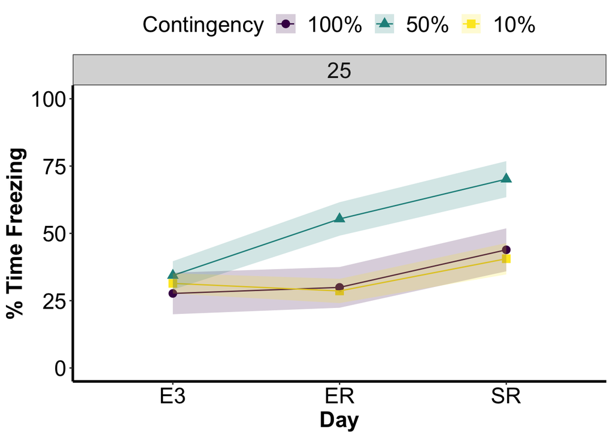

```r
ggplot(
  E3_ER_SR_ave_1,
  aes(x=Exp_Type,
      y=group_mean_freezing,
      group = Contingency,
      color = Contingency,
      fill = Contingency,
      shape = Contingency)) +
  scale_fill_viridis(discrete = TRUE) +
  scale_colour_viridis(discrete = TRUE) +
  geom_point(
    size = 3
  ) +
  geom_line(
  ) +
  facet_wrap(
    vars(CS_Time)
  ) +
  ylim(0,100) +
  geom_ribbon(
    aes(
      ymin = group_mean_freezing-se,
      ymax = group_mean_freezing+se),
    alpha = .2,
    color = NA
  ) +
  theme_bw() +
  theme(legend.text=element_text(size=18),
        legend.title = element_text(size=18),
        legend.position = "top",
        panel.border= element_blank(),
        plot.background = element_blank(),
        plot.title = element_text(size = 18,face="bold.italic", hjust=0.5),
        panel.grid.major = element_blank(),
        panel.grid.minor = element_blank(),
        axis.text.x = element_text(size = 18, color="black"),
        axis.text.y = element_text(size = 18, color="black"),
        axis.title.x = element_text(size = 18, face= "bold"),
        axis.title.y = element_text(size = 18, face="bold"),
        axis.line.x = element_line(color="black", size = 1),
        axis.line.y = element_line(color="black", size = 1),
        strip.text = element_text(size = 18)) +
  labs(
    x = "Day",
    y = "% Time Freezing")
```

### F - Stats

```r
m3f <- E3_ER_SR_id_1 %>%
  filter(Exp_Type !="E3") %>%
  aov_ez(id = "id",
         dv = "mean_freezing",
         between = "Contingency",
         within = "Exp_Type",
         data = .)
```

```
## Contrasts set to contr.sum for the following variables: Contingency
```

```r
#ANOVA table
nice_m3f <-nice(m3f)
kable(nice_m3f, caption = '<b>Figure 3F: Main FX</b>') %>%
  kable_styling(bootstrap_options = "striped", full_width = F, position = "left")
```

**Figure 3F: Main FX**

| Effect | df | MSE | F | ges | p.value |
| --- | --- | --- | --- | --- | --- |
| Contingency | 2, 21 | 345.52 | 11.31 *** | .351 | <.001 |
| Exp_Type | 1, 21 | 344.32 | 6.42 * | .132 | .019 |
| Contingency:Exp_Type | 2, 21 | 344.32 | 0.02 | .001 | .976 |

```r
#Simple contrasts for Contingency and Tone Test Day
n3f <- emmeans(m3f, ~Contingency * Exp_Type)
n3f_pairs <- pairs(n3f, simple="each")
kable(n3f_pairs[1], caption = '<b>Figure 3F: Simple Contrasts for Contingency</b>')
```

**Figure 3F: Simple Contrasts for Contingency**

| contrast | Exp_Type | estimate | SE | df | t.ratio | p.value |
| --- | --- | --- | --- | --- | --- | --- |
| 100% - 50% | ER | -25.420938 | 8.80355 | 21 | -2.8875782 | 0.0229734 |
| 100% - 10% | ER | 1.330625 | 8.80355 | 21 | 0.1511464 | 0.9874919 |
| 50% - 10% | ER | 26.751562 | 8.80355 | 21 | 3.0387246 | 0.0164774 |
| 100% - 50% | SR | -26.254375 | 9.74471 | 21 | -2.6942183 | 0.0348063 |
| 100% - 10% | SR | 3.313125 | 9.74471 | 21 | 0.3399922 | 0.9384542 |
| 50% - 10% | SR | 29.567500 | 9.74471 | 21 | 3.0342105 | 0.0166432 |

```r
kable(n3f_pairs[2], caption = '<b>Figure 3F: Simple Contrasts for Tone Test Day</b>')
```

**Figure 3F: Simple Contrasts for Tone Test Day**

| contrast | Contingency | estimate | SE | df | t.ratio | p.value |
| --- | --- | --- | --- | --- | --- | --- |
| ER - SR | 100% | -13.95813 | 9.277987 | 21 | -1.504435 | 0.1473619 |
| ER - SR | 50% | -14.79156 | 9.277987 | 21 | -1.594264 | 0.1258177 |
| ER - SR | 10% | -11.97563 | 9.277987 | 21 | -1.290757 | 0.2108182 |